# Pooling GRIM tests: an assumption ladder

The logic and mathematics of `grim_aggregate()` in the strait package

Author

Affiliation

Ian Hussey

University of Bern

# The problem

A single GRIM test is a clean deductive instrument. A reported mean either is or is not reachable as $S/(Nm)$ for some integer sum $S$ after rounding to the reported precision (Brown & Heathers, 2017). But forensic questions are rarely about one mean. They are about a paper, a lab, or a literature, and the question becomes: *what do many GRIM results say together?*

The naive summary, “3 of 20 means failed”, is hard to read for two reasons.

1. **Values differ in how much they can say.** At two decimals, a mean from $N = 12$ fails for 88% of possible endings. A mean from $N = 150$ can never fail. Counting passes treats both as evidence of the same weight.
2. **Every step beyond counting needs an assumption, and the assumptions differ in how defensible they are.** “Every failure is a problem” needs only that the rounding, items and extraction are right. “Fewer failures than random numbers would produce” needs a model of what random numbers look like. “About 30% of values are non-genuine” needs that model plus independence plus a mixture structure.

`grim_aggregate()` answers the pooling question as an **assumption ladder**. Each quantity is reported next to the assumptions it rests on. The reader climbs only as far as they are willing to defend. The deterministic rungs are the headline, and the model-based rungs are secondary.

# Notation and assumptions

Value $i = 1, \dots, n$ has reported mean $x_i$ with $d_i$ decimals, sample size $N_i$ and $m_i$ items. Means are supplied as **character** strings, so that trailing zeros fix $d_i$: `"5.10"` has $d = 2$, while `5.1` has lost that information. The rounding rule (default `"up_or_down"`) is used identically everywhere, for observed consistency and for pass rates.

Table 1: The assumptions, and the ways each can fail.

| Label | Assumption | Fails when |
| --- | --- | --- |
| **A0** | No authentic failures: correct values never fail GRIM | the rounding convention, items or $N$ are wrong, or a value was mis-extracted |
| **U** | Uniform counterfactual: a non-genuine value is equally likely to be any value on the reporting grid | fabricators favour or avoid particular digits |
| **I** | Independence: values pass or fail independently | a shared wrong $N$; copied or derived values |
| **M** | Mixture: each value is non-genuine with probability $\lambda$, otherwise correct | non-genuineness is clustered or structured |
| **B** | Authentic baseline: an authentic value fails with known probability $\varepsilon_i$ | the calibration corpus does not match the paper |

The rest of the document climbs the ladder one rung at a time, using a running example. The example is **illustrative only** and is not from any real paper. Nine of its twelve means are computed from integer sums, so they are genuine. The other three were chosen to fail GRIM.

```r
paper <- data.frame(
  x = c("3.39", "2.87", "4.12", "3.05", "2.65", "3.89",
        "1.93", "4.45", "3.27", "2.14", "3.71", "5.06"),
  n = c(28, 31, 45, 22, 37, 19, 26, 33, 41, 24, 150, 17)
)
res <- grim_aggregate(paper)
res
```

```
#> GRIM aggregation  (rounding = up_or_down, counterfactual = uniform)
#>  0  n_values                          12  none         values GRIM-tested
#>  1  mean_q                         0.644  none         mean fail rate q over tested values
#>  2  n_uninformative                    1  none         values that cannot fail (q = 0); excluded
#>     n_flagged_impossible               0  none         failures with q = 0: extraction errors; excluded
#>     k                                 11  none         informative values
#>     F                                  3  none         GRIM failures among informative values
#>  3  theta                   [0.273,1.00]  A0           share of informative values that are non-genuine
#>  4  E                               7.73  A0, U        failures expected if every value were random
#>  5  O_E                            0.388  A0, U        0 none; <1 fewer than random; 1 as random; >1 misfit
#>  6  var_F                           2.22  A0, U, I     variance of F if every value were random
#>     p_fewer_than_random          0.00341  A0, U, I     P(F' <= F): evidence against all-random
#>     p_more_than_random              1.00  A0, U, I     P(F' >= F): misfit of the random model
#>  7  lambda_moment                  0.388  A0, U, I, M  non-genuine rate, moment estimate (unbounded)
#>     lambda_mle                     0.380  A0, U, I, M  non-genuine rate, MLE on [0, 1]
#>  8  lambda_support_8      [0.0990,0.797]  A0, U, I, M  1/8 likelihood support interval
#>     lambda_support_32     [0.0573,0.912]  A0, U, I, M  1/32 likelihood support interval
#> Note: lambda is a process parameter; prefer steps 0-6 as the headline for a single paper.
```

# Rungs 0–2: counting (no assumptions)

## Rung 0: the GRIM result per value

$$c_i = \mathbb{1}\Big[\exists\, S \in \mathbb{Z} : \operatorname{round}_{d_i}\!\big(S / (N_i m_i)\big) = x_i\Big],
\qquad f_i = 1 - c_i .$$

This is computed by `scrutiny::grim_map()` (Jung, scrutiny package). No assumption is involved. It is arithmetic about the reported numbers.

## Rung 1: pass rate and fail rate

How often *could* value $i$ fail? Let $\text{grid}_d = \{0, 10^{-d}, \dots, 1 - 10^{-d}\}$ be the $10^d$ possible decimal endings. The pass rate is the share of endings that are consistent with the design:

$$p_i = \frac{1}{10^{d_i}} \sum_{j = 0}^{10^{d_i} - 1} c\big(j / 10^{d_i};\ N_i, m_i, d_i\big),
\qquad q_i = 1 - p_i .$$

**Why enumerating one unit interval is exact.** If $x$ is consistent through the sum $S$, then $x + 1$ is consistent through $S + N_i m_i$. Adding an integer to both the mean and to $S/(N_i m_i)$ shifts the rounding problem by a whole number, and that leaves the decimal ending unchanged. Consistency is therefore periodic with period 1 in $x$, and the $10^d$ endings in $[0, 1)$ are the whole story.

$p_i$ is a property of $(N_i, m_i, d_i, \text{rounding})$, not of the reported value. The package computes it by GRIM-testing every grid point with the same scrutiny call used for the observed values, so the rounding rule cannot drift between the two. Results are cached by design.

The familiar approximation is $q_i \approx \max(0, 1 - N_i m_i / 10^{d_i})$. This is what scrutiny’s `probability` column reports. It is exact unless $S/(Nm)$ can land exactly on a rounding tie. Under `"up_or_down"`, a tie is accepted in both directions, so the tie ending passes twice over and the exact pass rate is *higher*. At $d = 2$ this happens whenever $N m$ has a factor that puts $S/(Nm)$ on a $.xx5$. For example, at $N = 40$ the endings $.x25$ and $.x75$ are ties, and the exact $p$ is $0.60$ rather than $0.40$.

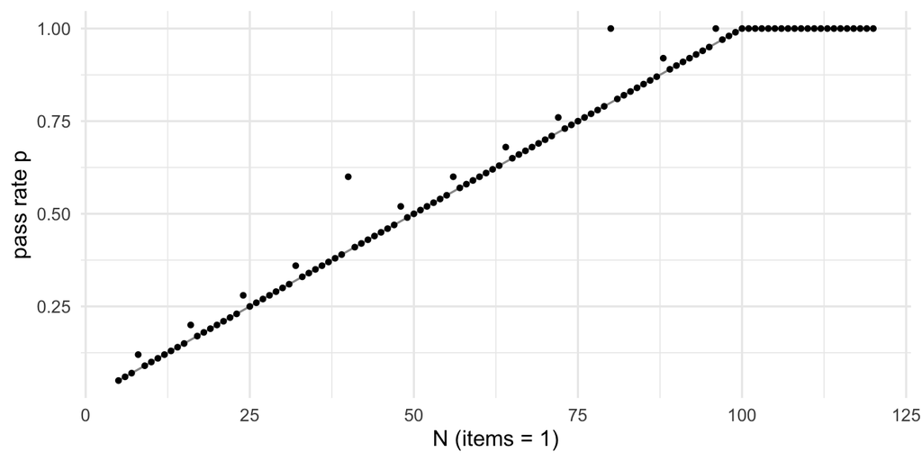

Figure 1: Exact GRIM pass rate at two decimals (points) against the closed-form approximation $\min(1, N/100)$ (line). The points above the line are sample sizes whose means can land exactly on a rounding tie.

```r
ns <- 5:120
pr <- grim_aggregate(data.frame(x = "1.00", n = ns))$data
ggplot(pr, aes(n, p_pass)) +
  geom_line(aes(y = pmin(1, n / 100)), colour = "grey60") +
  geom_point(size = 1) +
  labs(x = "N (items = 1)", y = "pass rate p")
```

With `items` $= m$, the relevant denominator is $N m$. A 4-item scale with $N = 30$ therefore behaves like $N = 120$: it cannot fail at two decimals.

## Rung 2: informative values, k and F

A value with $q_i = 0$ cannot fail. It carries no information about genuineness, and including it would dilute every rate below. So it is excluded and counted:

$$k = \#\{i : q_i > 0\}, \qquad F = \sum_{i:\, q_i > 0} f_i .$$

A value that fails even though $q_i = 0$ should be impossible: GRIM cannot fail on a full grid. Such a value signals a broken pipeline (a wrong $N$, a mis-typed value, a verdict pasted in from elsewhere). `grim_aggregate()` warns about it, flags it in `data$flag_impossible`, and excludes it.

In the example, the $N = 150$ mean is uninformative:

```r
res$data[, c("x", "n", "consistency", "p_pass", "q", "informative")]
```

```
#> # A tibble: 12 x 6
#>    x         n consistency p_pass     q informative
#>    <chr> <dbl> <lgl>        <dbl> <dbl> <lgl>
#>  1 3.39     28 TRUE         0.28   0.72 TRUE
#>  2 2.87     31 TRUE         0.31   0.69 TRUE
#>  3 4.12     45 FALSE        0.450  0.55 TRUE
#>  4 3.05     22 TRUE         0.22   0.78 TRUE
#>  5 2.65     37 TRUE         0.37   0.63 TRUE
#>  6 3.89     19 TRUE         0.19   0.81 TRUE
#>  7 1.93     26 FALSE        0.26   0.74 TRUE
#>  8 4.45     33 TRUE         0.33   0.67 TRUE
#>  9 3.27     41 TRUE         0.410  0.59 TRUE
#> 10 2.14     24 FALSE        0.28   0.72 TRUE
#> 11 3.71    150 TRUE         1.00   0    FALSE
#> 12 5.06     17 TRUE         0.17   0.83 TRUE
```

# Rung 3: a bound that needs only A0

Let $\theta$ be the proportion of informative values that are non-genuine, whether through error or fabrication. Under A0, every failure is non-genuine. A pass could be either, because a random value passes with probability $p_i$. So the number of non-genuine values $R$ satisfies $F \le R \le k$, and

$$\theta \in \left[\frac{F}{k},\ 1\right].$$

No probability is involved. The upper bound is always 1, and that is the point. Without a model of what non-genuine values look like, passes are silent. Everything that narrows this interval costs an assumption.

# Rungs 4–6: the random counterfactual

## Rung 4: expected failures (A0, U)

If every value were random on the grid, value $i$ would fail with probability $q_i$. The expected number of failures is

$$E = \sum_{i=1}^{k} q_i .$$

$E$ measures **how much information the set carries**. A paper whose means all come from large samples might have $k = 20$ and $E = 1.5$. Such a paper cannot say much in either direction, however its values behave. Report $E$ next to every ratio below.

## Rung 5: observed-to-expected ratio (A0, U)

$$O/E = \frac{F}{E}.$$

Expectations add whether or not the values are independent, so $O/E$ needs no assumption I. It is not capped at 1. Read it as follows:

| $O/E$ | Reading |
| --- | --- |
| 0 | no failures |
| $< 1$ | fewer failures than random values would produce |
| $\approx 1$ | as many as random values |
| $> 1$ | more failures than random values *can* produce: the uniform model misfits |

The last row is diagnostic. Random values cannot beat random. So $O/E$ well above 1 points at a systematic cause: a shared wrong $N$, a wrong rounding rule or number of items (which make $q_i$ wrong), or extraction errors. With small $E$ the ratio moves in steps of $1/E$. The package does not suppress it, but always read it next to $E$.

## Rung 6: the distribution of F under all-random (A0, U, I)

Adding independence gives the full null distribution. If every value is random, $F' = \sum f'_i$ with $f'_i \sim \text{Bernoulli}(q_i)$ independent, so

$$F' \sim \text{PoissonBinomial}(q_1, \dots, q_k), \quad
\mathbb{E}F' = E, \quad \operatorname{Var}F' = \sum q_i (1 - q_i).$$

The pmf is computed exactly by dynamic programming, one value at a time. Start from $P^{(0)} = (1)$ and update

$$P^{(i)}_j = P^{(i-1)}_j\,(1 - q_i) + P^{(i-1)}_{j-1}\, q_i .$$

Two one-sided tail probabilities follow:

- `p_fewer_than_random` $= P(F' \le F)$. Small values mean more passes than random values would produce, which is evidence against “every value is random”.
- `p_more_than_random` $= P(F' \ge F)$. Small values mean more failures than random values would produce, which is a misfit diagnostic (see rung 5).

These are randomisation-test statements about a *specified mechanism*, not inferences about a population.

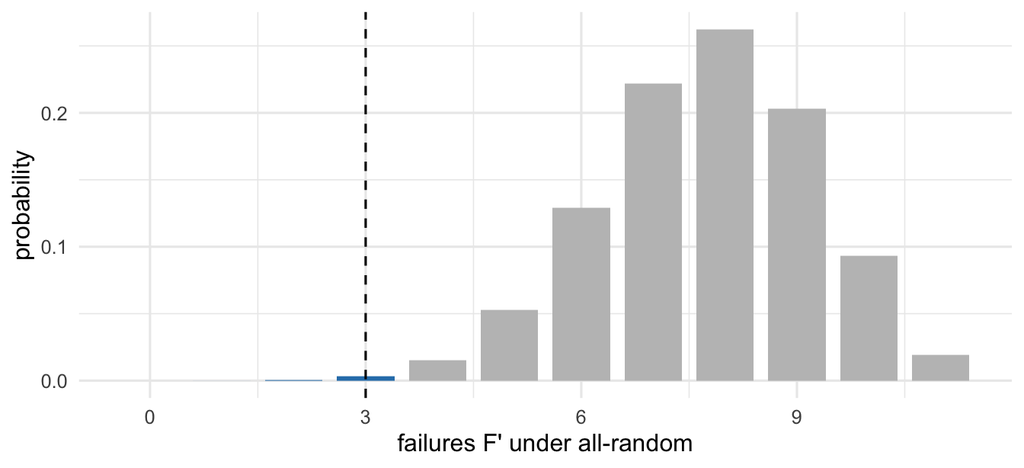

Figure 2: Distribution of the number of GRIM failures if every informative value in the example were uniform-random (Poisson binomial). The observed F is marked. The left tail up to it is `p_fewer_than_random`.

```r
qi <- res$data$q[res$data$informative]
F_obs <- sum(res$data$f[res$data$informative])
pmf <- data.frame(F = 0:length(qi), p = strait:::.poisbinom_pmf(qi))
ggplot(pmf, aes(F, p, fill = F <= F_obs)) +
  geom_col(width = 0.8) +
  scale_fill_manual(values = c(`TRUE` = "#2c7fb8", `FALSE` = "grey75"),
                    guide = "none") +
  geom_vline(xintercept = F_obs, linetype = 2) +
  labs(x = "failures F' under all-random", y = "probability")
```

# Rungs 7–8: a mixture model for the non-genuine rate (A0, U, I, M)

Rung 6 asks whether *all* values could be random. A more useful model lets only some of them be. Suppose each value is independently non-genuine with probability $\lambda$, and a non-genuine value is uniform on the grid. Under A0, a genuine value never fails, so

$$P(f_i = 1) = \lambda\, q_i ,
\qquad
\ell(\lambda) = \sum_i \Big[ f_i \log(\lambda q_i) + (1 - f_i) \log(1 - \lambda q_i) \Big].$$

## Rung 7: estimators

- **Moment estimator.** $\mathbb{E}F = \lambda E$, so $\tilde\lambda = F/E = O/E$ is unbiased under M. It is also unbounded: values above 1 are the misfit signal of rung 5.
- **Maximum likelihood** on $[0, 1]$. $\hat\lambda = 0$ if $F = 0$ and $\hat\lambda = 1$ if $F = k$. Otherwise, $\ell$ is concave (a sum of logs of linear functions), so $\hat\lambda$ solves
  $$\ell'(\lambda) = \frac{F}{\lambda} - \sum_{i:\, f_i = 0} \frac{q_i}{1 - \lambda q_i} = 0,$$
  or equals 1 if $\ell'(1) \ge 0$. When all $q_i = q$, this gives $F(1 - \lambda q) = (k - F)\lambda q$, so $\hat\lambda = \min(1, F/(kq)) = \min(1, O/E)$.

The cap at 1 biases $\hat\lambda$ **downward** when $kq$ is small, because the upper tail of $F/E$ is truncated while the lower tail is not (see Figure 4).

## Rung 8: intervals

The default is a **likelihood support interval** (Royall, 1997):

$$\big\{ \lambda \in [0, 1] : \ell(\lambda) \ge \ell(\hat\lambda) - \log c \big\},
\qquad c \in \{8, 32\}.$$

These are the values of $\lambda$ that are no more than $c$ times less likely than $\hat\lambda$. When $F = 0$ the lower end is 0. Optionally (`ci = TRUE`), a confidence interval inverts the Poisson-binomial tails with rates $\lambda q_i$. The lower bound solves $P(F' \ge F \mid \lambda) = \alpha/2$ and the upper bound solves $P(F' \le F \mid \lambda) = \alpha/2$.

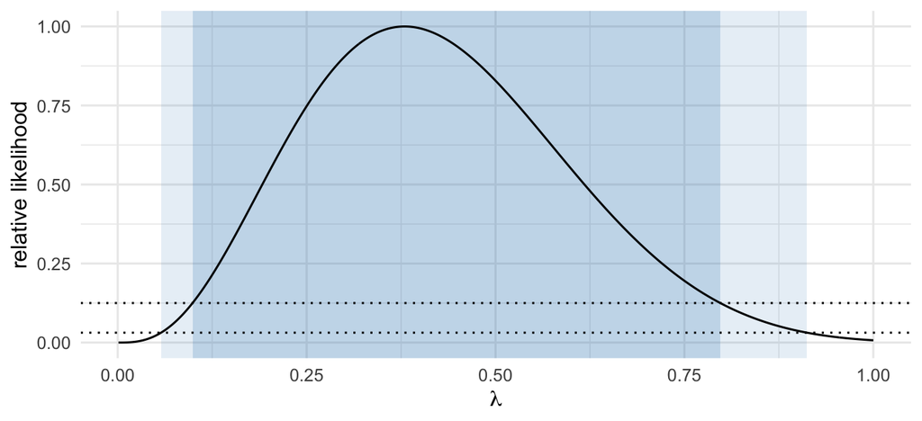

Figure 3: Relative likelihood of the non-genuine rate λ for the example, with the 1/8 and 1/32 support intervals shaded.

```r
fi <- res$data$f[res$data$informative]
lam <- seq(0.001, 1, length.out = 400)
ll <- vapply(lam, strait:::.lambda_loglik, 0, f = fi, q = qi)
s <- res$summary
si <- function(nm) unlist(s[s$quantity == nm, c("lower", "upper")])
ggplot(data.frame(lam, rl = exp(ll - max(ll))), aes(lam, rl)) +
  annotate("rect", xmin = si("lambda_support_32")[1],
           xmax = si("lambda_support_32")[2], ymin = -Inf, ymax = Inf,
           alpha = 0.12, fill = "#2c7fb8") +
  annotate("rect", xmin = si("lambda_support_8")[1],
           xmax = si("lambda_support_8")[2], ymin = -Inf, ymax = Inf,
           alpha = 0.2, fill = "#2c7fb8") +
  geom_line() +
  geom_hline(yintercept = c(1 / 8, 1 / 32), linetype = 3) +
  labs(x = expression(lambda), y = "relative likelihood")
```

**$\lambda$ is a process parameter.** It describes the rate of a mechanism that generates values. That makes it natural for pooled analyses across many papers, where “what share of values in this literature are non-genuine?” is a meaningful question. For a single paper, the interval is usually wide, and the headline should be rungs 0–6. The print method says so whenever rung 8 is shown.

# Rung 9: comparison with an authentic baseline (B)

Assumption A0 is an idealisation. In real corpora, some authentic values fail because of rounding conventions, unreported item counts and typos. Suppose an external calibration supplies the probability $\varepsilon_i$ that an *authentic* value fails, for example from a reference corpus with verified raw data. Then

$$E_A = \sum_i \varepsilon_i, \qquad
\mathrm{SIR} = \frac{F}{E_A}, \qquad
\texttt{p\_vs\_baseline} = P(F' \ge F), \ F' \sim \text{PoissonBinomial}(\varepsilon_1, \dots, \varepsilon_k).$$

The standardized inconsistency ratio (SIR) is the observed-to-expected ratio against authentic data rather than random data. If the baseline is a fixed fraction of the random rate, $\varepsilon_i = \tau q_i$, then $E_A = \tau E$ and $\mathrm{SIR} = (O/E)/\tau$.

$\varepsilon$ is deliberately kept out of rungs 0–8. Those rungs are about what the numbers themselves imply. Rung 9 is only as good as the calibration corpus.

```r
# illustrative baseline: authentic values fail at 3% of the random rate
grim_aggregate(paper, eps = function(q, n, d) 0.03 * q)$summary |>
  subset(step == 9, select = c(quantity, value, assumptions))
```

```
#> # A tibble: 3 x 3
#>   quantity         value assumptions
#>   <chr>            <dbl> <chr>
#> 1 E_A            0.232   B
#> 2 SIR           12.9     B
#> 3 p_vs_baseline  0.00136 B, I
```

# Sensitivity to the counterfactual

Assumption U says that a non-genuine value is uniform on the grid. People who invent numbers are not uniform: they avoid or favour particular final digits (Mosimann et al., 1995). The `g` argument replaces the uniform distribution with any distribution over the grid:

$$p_i(g) = \sum_{j} g(j)\, c\big(j / 10^{d_i};\ N_i, m_i, d_i\big),$$

given either as a function of the final digit or as one weight per grid value. `grim_sensitivity()` reruns rungs 2–6 under a list of counterfactuals:

```r
grim_sensitivity(paper, list(
  avoid_0_5   = function(d) ifelse(d %in% c(0, 5), 0.3, 1),
  heap_0_5    = function(d) ifelse(d %in% c(0, 5), 4, 1),
  heap_even   = function(d) ifelse(d %% 2 == 0, 3, 1),
  round_tenth = c(rep(c(20, rep(1, 9)), 10))  # heaps on .x0 endings
))
```

```
#> # A tibble: 5 x 7
#>   counterfactual     k     F     E   O_E p_fewer_than_random p_more_than_random
#>   <chr>          <dbl> <dbl> <dbl> <dbl>               <dbl>              <dbl>
#> 1 uniform           11     3  7.73 0.388             0.00341              1.000
#> 2 avoid_0_5         11     3  7.69 0.390             0.00363              1.000
#> 3 heap_0_5          11     3  7.81 0.384             0.00288              1.000
#> 4 heap_even         11     3  7.69 0.390             0.00361              1.000
#> 5 round_tenth       11     3  7.97 0.376             0.00164              1.000
```

Preferences over the **final digit** barely move anything at $N < 100$. The consistent endings for a given $N$ spread almost evenly across final digits, so reweighting digits leaves $p_i$ nearly unchanged. Two things would move it. One is a counterfactual that concentrates on endings that the design happens to favour or disfavour. The other is a small $N$, where only a few endings are consistent. Either way, running the check costs nothing, and conclusions that survive it do not depend on U in this form.

# Many papers at once

`grim_aggregate_by()` runs the ladder within groups and returns one row per group. Across papers, the per-paper $\lambda$ intervals are best read as inputs to a pooled analysis rather than as verdicts.

```r
set.seed(1)
make_paper <- function(id, k, lambda) {
  n <- sample(12:95, k, replace = TRUE)
  fake <- runif(k) < lambda
  x_real <- vapply(n, function(nn) sample(nn:(5 * nn), 1) / nn, 0)
  x_fake <- sample(100:599, k, replace = TRUE) / 100
  data.frame(paper = id, n = n,
             x = formatC(ifelse(fake, x_fake, x_real), format = "f", digits = 2))
}
lit <- do.call(rbind, Map(make_paper, LETTERS[1:6],
                          k = c(8, 15, 20, 10, 25, 12),
                          lambda = c(0, 0, 0.1, 0, 0.6, 1)))
by_paper <- grim_aggregate_by(lit, by = "paper")
by_paper[, c("paper", "k", "F", "theta_lower", "E", "O_E",
             "p_fewer_than_random", "lambda_mle")]
```

```
#> # A tibble: 6 x 8
#>   paper     k     F theta_lower     E   O_E p_fewer_than_random lambda_mle
#>   <chr> <dbl> <dbl>       <dbl> <dbl> <dbl>               <dbl>      <dbl>
#> 1 A         8     0       0      3.72 0             0.00187          0
#> 2 B        15     0       0      6.76 0             0.0000562        0
#> 3 C        20     0       0      9.26 0             0.000000521      0
#> 4 D        10     0       0      5.16 0             0.000205         0
#> 5 E        25     6       0.24   9.64 0.622         0.0688           0.670
#> 6 F        12     4       0.333  3.52 1.14          0.760            1
```

These are simulated papers with true $\lambda$ = 0, 0, 0.1, 0, 0.6 and 1. Paper F, with every value random, shows $O/E$ near 1 and a large `p_fewer_than_random`. Paper E shows the intermediate signature. The genuine papers show $O/E = 0$. So does paper C: its one or two non-genuine values happened to pass. A low rate of non-genuine values is often invisible in a single paper, which is one reason $\lambda$ belongs to pooled analyses.

# Calibration

Under the mixture model, $\mathbb{E}(O/E) = \lambda$ exactly for fixed $q_i$, and $\hat\lambda$ is pulled down by its cap. A small simulation checks both, for a low-information design ($k = 6$) and a high-information one ($k = 30$), with all $N$ between 12 and 60 at two decimals.

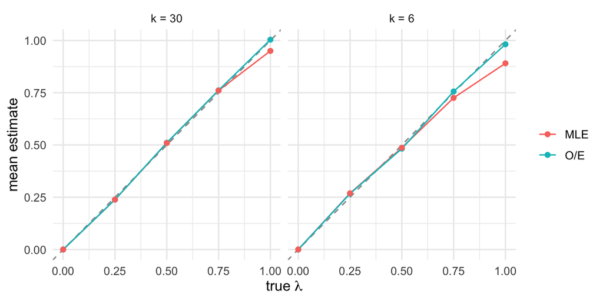

Figure 4: Simulated O/E (unbiased, unbounded) and MLE (capped at 1) against the true non-genuine rate λ. Points are means over 300 replicates; the dashed line is identity. The MLE’s downward bias at high λ shrinks as the design becomes more informative.

```r
set.seed(20260927)
sim_design <- function(k, lambda, reps = 300) {
  n <- round(seq(12, 60, length.out = k))
  est <- replicate(reps, {
    fake <- runif(k) < lambda
    x_real <- vapply(n, function(nn) sample(nn:(5 * nn), 1) / nn, 0)
    x_fake <- sample(100:599, k, replace = TRUE) / 100
    x <- formatC(ifelse(fake, x_fake, x_real), format = "f", digits = 2)
    s <- grim_aggregate(data.frame(x = x, n = n))$summary
    s$value[match(c("O_E", "lambda_mle"), s$quantity)]
  })
  data.frame(k = paste0("k = ", k), lambda = lambda,
             estimator = c("O/E", "MLE"), mean = rowMeans(est))
}
cal <- do.call(rbind, c(
  lapply(c(0, 0.25, 0.5, 0.75, 1), sim_design, k = 6),
  lapply(c(0, 0.25, 0.5, 0.75, 1), sim_design, k = 30)
))
ggplot(cal, aes(lambda, mean, colour = estimator)) +
  geom_abline(linetype = 2, colour = "grey60") +
  geom_line() + geom_point() +
  facet_wrap(~k) +
  labs(x = expression("true " * lambda), y = "mean estimate", colour = NULL)
```

# What not to conclude

- **A single failure under A0 is not proof of fabrication.** It is proof that the reported numbers are inconsistent *given* the assumed rounding, items and $N$. Rung 3’s lower bound inherits that caveat.
- **O/E well above 1 is not “extra-strong evidence”.** It says the uniform model is wrong, most often because $q_i$ is wrong (rounding, items) or because failures share a cause (one wrong $N$ behind several means).
- **Independence is assumed only where listed.** Rungs 0–5 do not use it. Rungs 6–8 do, and derived or copied values break it.
- **Per-paper $\lambda$ is not the headline.** Report rungs 0–6 for a paper, and keep $\lambda$ for pooled analyses.

# Function reference

| Function | Returns |
| --- | --- |
| `grim_aggregate(data, items, rounding, g, eps, support_c, ci, conf_level)` | `summary` (long tibble, one row per quantity, in ladder order, with `assumptions` and `interpretation`) and `data` (input plus `consistency`, `f`, `p_pass`, `q`, `informative`, `flag_impossible`) |
| `grim_aggregate_by(data, by, ...)` | one wide row per group |
| `grim_sensitivity(data, g_list, ...)` | $k$, $F$, $E$, $O/E$ and both tail probabilities under each counterfactual |

# References

Brown, N. J. L., & Heathers, J. A. J. (2017). The GRIM test: A simple technique detects numerous anomalies in the reporting of results in psychology. *Social Psychological and Personality Science, 8*(4), 363–369.

Jung, L. scrutiny: Error detection in science (version 0.6.2). R package. https://github.com/lhdjung/scrutiny

Mosimann, J. E., Wiseman, C. V., & Edelman, R. E. (1995). Data fabrication: Can people generate random digits? *Accountability in Research, 4*(1), 31–55.

Royall, R. (1997). *Statistical evidence: A likelihood paradigm*. Chapman & Hall.